# OSI Panthera, camera trap analyses

Julie Rode, Claire Lambert, Lucile Marescot, Bastien Chaix, Julie Beesau, Suzanne Bastian, Anne-Lise Cabanat

2021-03-18 15:24:14

# 1 Data Import and formating

I used the excel file named “Données_PP_Naryn_2016_2019”

Here we load the required libraries

```r
library(ggplot2)
library(showtext)
library(readxl)
library (plyr)
library (tidyverse)
library(egg)
library(sf)
library(ggsn)
library(scatterpie)
library(adehabitatHR)
library(lubridate)
```

Here we import the necessary data, camera trap detections fill and Kyrgyzstan shapefile.

Notice that I made some few change directly on the raw data. otherwise most of the formating is done directly in the script  
I reverse Longitude and Latitude in the excel sheet as the label seemed to have been reversed (Only after I changed the columns names, that trap locations fell into Kirgizstan shpefile).

The long lat coordinates had sometimes two points .. or two comas ,, So I standardized all coordinates into the standard WGS84 long/lat format and made sure they were all ranging between xmin: 69.27661 ymin: 39.17283 xmax: 80.28316 ymax: 43.23822 which corresponds to Kirgizstan Limits

```r
path<-"C:/Users/DELL/Documents/Documents/OSI/OSI Panthera"
pathdata <- paste0(path, "/Données_PP_Naryn_2016_2019.xlsx")


world <- st_read(paste0(path, "/countries.shp"))
Kyrgyzstan <- world[world$NAME=="Kyrgyzstan",]


sheetnames <- excel_sheets(paste0(path, "/Données_PP_Naryn_2016_2019.xlsx"))
mylist <- lapply(excel_sheets(pathdata), read_excel, path = pathdata)

# name the dataframes
names(mylist) <- sheetnames
```

Here we create a function to duplicate info on camera trap ID, coordinates, Place and elevation for all missing cells. Basically the function aims at filling all the NA generated once we imported the excel file, which had a lot of merged cells. Then we take each sheet coresponding to the year of data collection and bind them into a list, then into a single data frame.

We also correct typos in SL.Names and on Latitude coordinates 41.39.93 or 41,39,93 Convert the Day, month, year into date format and correct dates misrecorded as 2015

```r
duplicateinfo<-function(x){
  for(i in 2:nrow(x))
  {
    if(is.na(x$`N° trap camera`[i]))
      x$`N° trap camera`[i]<-x$`N° trap camera`[i-1]
    if(is.na(x$Place[i]))
      x$Place[i]<-x$Place[i-1]
    if(is.na(x$Longitude[i]))
      x$Longitude[i]<-x$Longitude[i-1]
    if(is.na(x$Latitude[i]))
      x$Latitude[i]<-x$Latitude[i-1]
    if(is.na(x$`Elevation (m)`[i]))
      x$`Elevation (m)`[i]<-x$`Elevation (m)`[i-1]
  }

  return(x)
}

newlist<-lapply(mylist, duplicateinfo)


#put everything into a dataframe
#df <- do.call(rbind.data.frame, newlist)
df <- ldply (newlist, data.frame)

#remove uncessariy colums
#df<- df %>% select(-Behaviour...Observations)
#Becarefull between 250 and 2019 many Longitude has two comas, might woth checking the GPS coordinate
df$LongitudeOK<-df$Latitude
df$Latitude<-df$Longitude
df$Latitude<- str_replace(df$Latitude, ",39,", ".39")
df$Latitude<- str_replace(df$Latitude, ".39.93", ".3993")

df$Latitude<- str_replace(df$Latitude, ",", ".")

df$Longitude<-df$LongitudeOK
#converte date
df<-df %>% mutate(Day=as.numeric(str_replace(Day, "/",  "")), Month= as.numeric(str_replace(Month, "/",  "")), Year=as.numeric(str_replace(Year, "/",  "")))

df$Year[7:22]<-2018
df$D<-df$Day
df$Day[7:22]<-df$Month[7:22]
df$Month[7:22]<-df$D[7:22]


df<- df %>% mutate(date=ymd(paste0(Year,"/", Month,"/", Day)))



#Here for the pictures collected in 2019, I added 4 years and 43 days to any date recorded as 2015
df$date[which(df$.id=="2019" & year(df$date)==2015)] <-
  df$date[which(df$.id=="2019" & year(df$date)==2015)] + 1503

# For those collected in 2017 I simply added 2 years assuming the winter day was correct
df$date[which(df$.id=="2017" & year(df$date)==2015)] <-
  df$date[which(df$.id=="2017" & year(df$date)==2015)] + 730
df$Year<-year(df$date)
df$Year[7:22]<-2018

df<- df %>% mutate(time=ymd_hms(Hour))
df<- df %>% mutate(hours=hms(paste0(hour(Hour),"/", minute(Hour), "/", second(Hour))))


df<- df %>% mutate(date_hour=(paste0(date,"_", hours)))
#df<- df %>% mutate(date_hour=ymd_hms(date_hour))


date(df$Hour)<-df$date

df <- df %>% arrange(rev(desc(Hour)))

picdet<-data.frame(Trap=NULL, Numpic=NULL)

for(j in unique(df$N..trap.camera))
{
  df.sub<- df %>% filter(df$N..trap.camera==j)
  df.sub <- df.sub %>% arrange(rev(desc(Hour)))

  inc<-0
  inc2<-1

  i<-1
  while(i < nrow(df.sub))
  {

      while(difftime(df.sub$Hour[i+inc2],df.sub$Hour[i], tz, units ="mins") <= 15)
    {
      inc2<-inc2+1
      if((i+ inc2) > nrow(df.sub)) break
    }
    inc <-inc +1

    i <- i + inc2

    inc2<-1
  }
  picdet<-rbind(picdet, c(j,inc))
}


# correct typos on names
df$SL.Name[df$SL.Name=="Ayana "] <- "Ayana"

df$SL.Name<- str_replace(df$SL.Name, "cub",  "Cub")
df$SL.Name<- str_replace(df$SL.Name, "Illguiz",  "Ilguiz")
df$SL.Name[df$SL.Name=="Cub a"] <- "Aika's 3 cub"
df$SL.Name[df$SL.Name=="Cub b"] <- "Aika's 3 cub"
df$SL.Name[df$SL.Name=="Cub c"] <- "Aika's 3 cub"
df$SL.Name[df$SL.Name=="Cub b ou c"] <- "Aika's 3 cub"
df$SL.Name[df$SL.Name=="Cub a,b ou c"] <- "Aika's 3 cub"
df$SL.Name[df$SL.Name=="Cub a, b ou c"] <- "Aika's 3 cub"
df$SL.Name[df$SL.Name=="Cub  a,b ou c"]<- "Aika's 3 cub"
df$SL.Name[df$SL.Name=="Cub AY6"] <- "Ayana's 2 cubs"
df$SL.Name[df$SL.Name=="Cub ay1"] <- "Ayana's 2 cubs"
df$SL.Name[df$SL.Name=="Subadult NI"] <- "Ilguiz's cub"
df$SL.Name[df$SL.Name=="Cub NI"]<- "Ilguiz's cub"

df$Latitude<-as.numeric(df$Latitude)

df$Longitude<-as.numeric(df$Longitude)
```

# 2 Mapping Data

We convert data frame into spatial data frame and start to visualize the spatial data.

first, let’s locate the study area in Kirgiztan

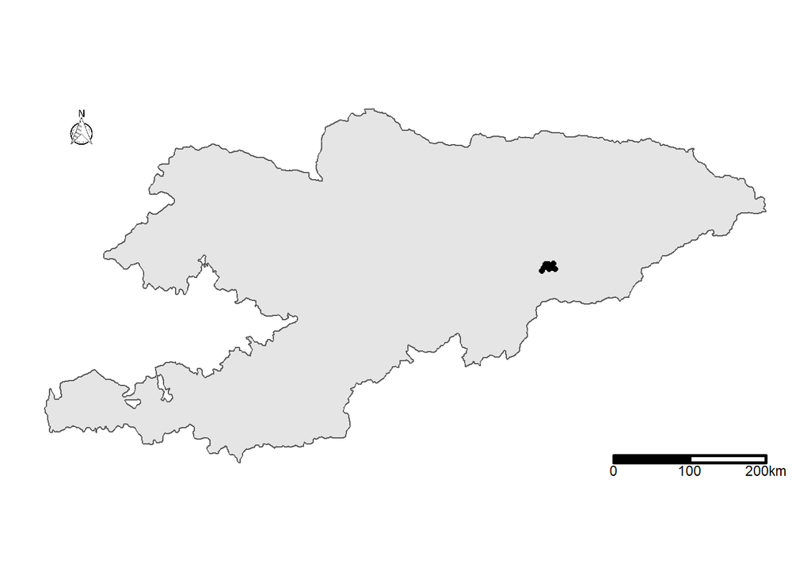

```r
df.sf<-st_as_sf(df, coords = c("Longitude", "Latitude"), crs = 4326)


#plot(df.space)
#df.sf<-as(df.space, "sf")

ggplot() + geom_sf(data=Kyrgyzstan) +
  geom_sf(data=df.sf) +   north(Kyrgyzstan,  location = "topleft") +
  scalebar(Kyrgyzstan, dist = 100, st.size=3, dist_unit = "km", transform = TRUE, model = "WGS84") +
  coord_sf(crs = st_crs(Kyrgyzstan),  datum = NA) +
  theme(
    panel.ontop = FALSE,   ## Note: this is to make the panel grid visible in this example
    panel.grid = element_blank(),
    line = element_blank(),
    rect = element_blank(),
    text = element_blank(),
    plot.background = element_rect(fill = "white")) + labs(colour="Camera trap")
```

Minimum Convex Polygon common estimators of the minimum home range size, but can potentially include area not used by the animal and overestimate the home range. Reversely it can overlook some non detected area used by the animal. The function worked only for 3 individuals. There was not enough locations for the others.

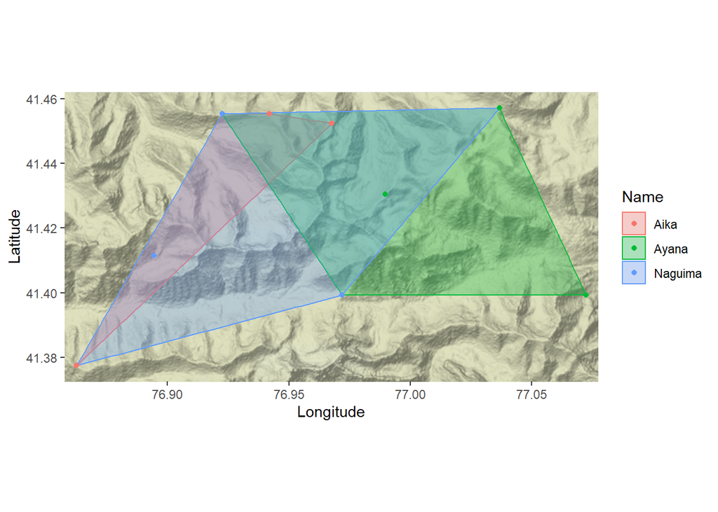

```r
Panthera.sp <- df[, c("SL.Name", "Longitude", "Latitude")]

Panthera.sp <- Panthera.sp %>% filter(SL.Name=="Aika" | SL.Name=="Ayana" | SL.Name=="Naguima")


library(sp)
coordinates(Panthera.sp) <- c("Longitude", "Latitude")

# Set the coordinate reference system (CRS)
# More information on CRS here:
# https://www.nceas.ucsb.edu/~frazier/RSpatialGuides/OverviewCoordinateReferenceSystems.pdf
# The sample data are UTM points in WGS84 from zone 18N
proj4string(Panthera.sp) <-  CRS("+proj=longlat +datum=WGS84 +no_defs +ellps=WGS84 +towgs84=0,0,0")

# Calculate MCPs for each turtle
Panthera.mcp <- mcp(Panthera.sp, percent = 100)

# Examine output
#Panthera.mcp

# Plot
library(scales) # Helps make polygons partly transparent using the alpha argument below
#plot(Panthera.sp, col = as.factor(Panthera.sp@data$id), pch = 16)
#plot(Panthera.mcp, col = alpha(1:5, 0.5), add = TRUE)

#hrs <- mcp.area(Panthera.sp, percent = seq(50, 100, by = 5))


Panthera.spgeo <- spTransform(Panthera.sp, CRS("+proj=longlat"))
Panthera.mcpgeo <- spTransform(Panthera.mcp, CRS("+proj=longlat"))

library(ggmap)

mybasemap <- get_stamenmap(bbox = c(left = min(Panthera.spgeo@coords[,1])-0.005,
                                    bottom = min(Panthera.spgeo@coords[,2])-0.005,
                                    right = max(Panthera.spgeo@coords[,1])+0.005,
                                    top = max(Panthera.spgeo@coords[,2])+0.005),
                           zoom = 12)

Panthera.geo <- data.frame(Panthera.spgeo@coords, id = Panthera.spgeo@data$SL.Name)

mymap.hr <- ggmap(mybasemap) +
  geom_polygon(data = fortify(Panthera.mcpgeo),
               # Polygon layer needs to be "fortified" to add geometry to the dataframe
              aes(long, lat, colour = id, fill=id),
              alpha = 0.3) + # alpha sets the transparency
  geom_point(data = Panthera.geo,
             aes(x = Longitude, y = Latitude, colour = id))

mymap.hr +
  theme(legend.position = "right") +
  labs(x = "Longitude", y = "Latitude", color = "Name", fill="Name")
```

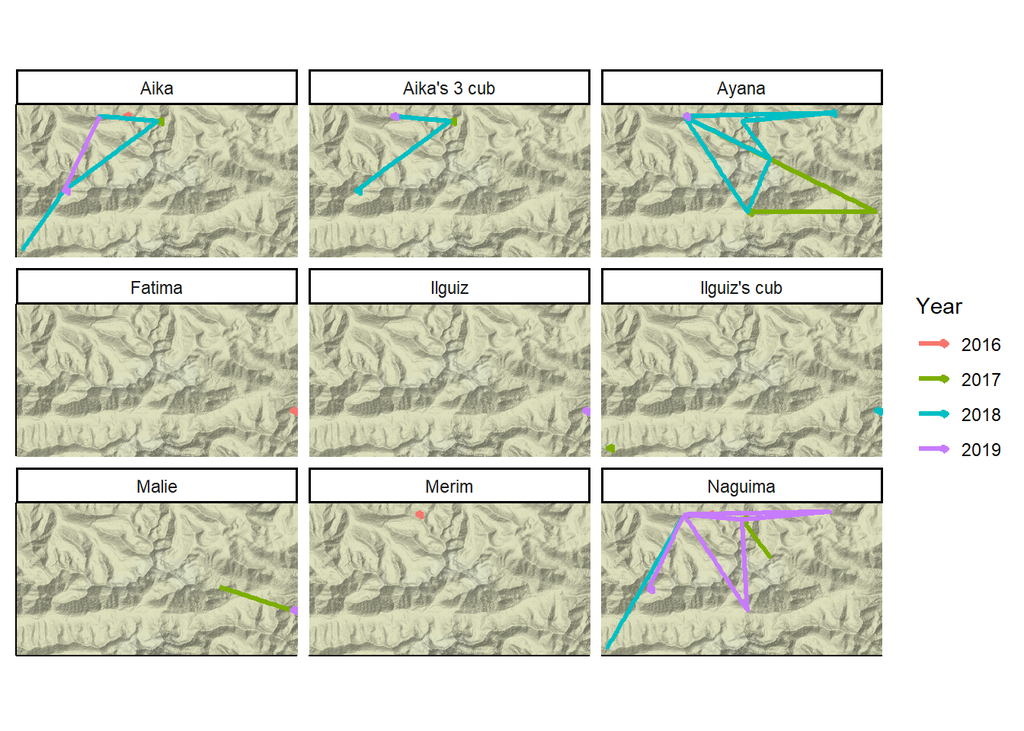

```r
df$Year<-as.character(df$Year)


df.filt.bis<-df %>% filter(SL.Name!="/" &  SL.Name!="Mishka" &  SL.Name!="Aida")

ggmap(mybasemap)  +  geom_path(data=df.filt.bis, aes(x = Longitude, y = Latitude, group=Year, color = Year), size=1.1, arrow = arrow(angle=30,length=unit(0.1,"cm"), type="closed"))  + facet_wrap(~SL.Name) +   theme_classic()  + theme_classic() +  theme(axis.title.x = element_blank(), axis.title.y = element_blank(), axis.ticks.x = element_blank(), axis.ticks.y = element_blank(), axis.text=element_blank(), legend.position="right")
```

```r
#ggsave("C:/Users/DELL/Documents/Documents/OSI/OSI Panthera/figures/fig_2.pdf", width = 8, height = 5, dpi=300)
```